# Introdução à Bioestatística

**[Prof. Wagner Tassinari (DEMAT/UFRRJ)](https://institucional.ufrrj.br/ruralpesquisa/wagner-de-souza-tassinari/)**

email: *tassinari@ufrrj.br*

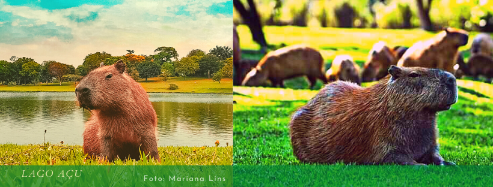

Esta página representa o repositório do conteúdo da disciplina de Introdução à Bioestatística (DEMAT/UFRRJ)

# Informações Gerais

## Objetivo das Disciplinas

- Introduzir os conceitos básicos introdutórios da disciplina de bioestatística, dando ênfase às aplicações nas áreas da saúde, biológicas e ciências animais.

## Formato das Disciplinas

- O curso será no formato presencial.

## Sobre o pacote estatístico R

- Neste curso também está previsto a utilização do **pacote estatístico R** utilizando a interface gráfica do **RStudio**. O pacote estatístico R, que pode ser encontrado no site oficial do projeto CRAN ([link](https://cran.r-project.org/)). O pacote estatístico R é uma linguagem de programação estatística e gráfica direcionada para a manipulação, visualização e análise estatística de dados, que atualmente vem sendo considerada uma das melhores ferramentas para essa finalidade. A linguagem ainda possui como diferencial a facilidade no aprendizado, mesmo para aqueles que nunca tiveram contato anterior com programação. O pacote estatístico R é um *software* livre (*free*) e de código aberto (*open source*) para análise de dados.
- Uma das formas de utilizar a linguagem R é através da interface gráfica **RStudio** ([link](https://rstudio.com/products/rstudio/)), que é uma IDE ou ambiente de desenvolvimento integrado, para o pacote R. Com sua utilização gratuita, o RStudio é uma excelente ferramenta para trabalhar com o R. Essa plataforma é extremamente visual quando comparado com ambientes de outras linguagens e também com o console do R, e muito simples de se utilizar.
- Uma outra opção para trabalhar com o pacote estatístico R é a versão mobile do R: [R Programming Compiler](https://play.google.com/store/apps/details?id=com.krazeapps.rprogrammingcompiler)

# Programa das Disciplinas

- Introdução à Estatística
- Apresentação dos dados em Tabelas e Gráficos
- Medidas de Tendência Central
- Medidas de Dispersão
- Associação entre duas Variáveis
- Introdução à Probabilidade
- Variáveis Aleatórias
- Modelo de Dist. Probabilidades para VA Discretas e Contínuas
- Introdução à Inferência Estatística

**OBS2:** É facultativa ao aluno uma prova opcional (optativa), a ser realizada no encerramento do período, envolvendo toda a matéria lecionada. A nota obtida em prova opcional substituirá o de menor valor correspondente às verificações regulares durante o período, inclusive se o grau da prova optativa for inferior ao menor conceito obtido anteriormente, mas esta substituição deve resultar em média final igual ou superior a $5,0$ (cinco). [(Ver manual do estudante da UFRRJ)](https://portal.ufrrj.br/wp-content/uploads/2015/09/Manual-FINAL.pdf)

# Bibliografias

## Bibliografia Básica

- Wilton O. Bussab; Pedro A. Morettin. **Estatística Básica**. Editora Saraiva
- Sonia Vieira. **Introdução à Bioestatística**. Editora Elsevier

## Bibliografia Sugerida

- [Diógenes Ferreira Filho. **Apostila de Estatística Básica**, UFRRJ. 2017](https://drive.google.com/file/d/1eo4CWWqZzNibXqNK4bfUxZXzqwEgufIl/view?usp=drivesdk)
- [Vu, J; Harrington, D. **Introductory Statistics for the Life and Biomedical Sciences**, 1ª edição. 2020.](https://leanpub.com/biostat)
- [Diez, DM; Barr, C D; Çetinkaya-Rundel M. **OpenIntro Statistics**, 3ª edição. 2015.](https://leanpub.com/openintro-statistics)

# Instalando o pacote estatístico R + sua interface gráfica RStudio

- [Video mostrando sites para download do R](https://www.youtube.com/watch?v=waiNuVtj9-U)
- [Vídeo mostrando como instalar Rstudio no Windows](https://www.youtube.com/watch?v=aeK6-kPhofk)
- [Vídeo mostrando como instalar o R + Rstudio no Windows](https://www.youtube.com/watch?v=PWMqxKWHlz4&t=207s)
- [Vídeo mostrando o tutorial sobre compilador do R para celular](https://www.youtube.com/watch?v=plF3TUEw0Lg)

# Conteúdo das aulas

## **Aula 1:** Conceitos Básicos

- Nessa aula serão apresentados alguns conceitos fundamentais para se trabalhar com as principais ferramentas da análise estatística.

| Atividades | Tipo de Atividade | Links |
| --- | --- | --- |
| Slides | Slides sobre a Aula de Apresentação da Disciplina | [link](https://drive.google.com/file/d/11vxOoONjd_inTxZ4of3Brft9Js5_WRWk/view?usp=sharing) |
| Slides | Slides sobre a Aula 1 | [link](https://drive.google.com/file/d/1NhAgK6ZEiOdUpIhaTHj7wH3DdBDzL69n/view?usp=sharing) |

## **Aula 2:** Apresentação dos dados em tabelas

- Nessa aula serão apresentados técnicas de como se apresentar os dados organizados em tabelas.

| Atividade | Tipo de Atividade | Links |
| --- | --- | --- |
| Slides | Slides sobre a Aula 2 | [link](https://drive.google.com/file/d/1NzMhSjiHqxEZdF7a-I_spQoRRbrJ0nUa/view?usp=sharing) |
| Exercícios | Lista de exercícios sobre a aula 2 | [link](https://drive.google.com/file/d/1DJ32hbl_lTSNMKKQCdZmeQ-trooQc1xC/view?usp=sharing) |

## **Aula 3:** Apresentação dos dados em gráficos

- Nessa aula serão apresentados técnicas de como se apresentar os dados organizados em gráficos.

| Atividade | Tipo de Atividade | Links |
| --- | --- | --- |
| Slides | Slides sobre a Aula 3 | [link](https://drive.google.com/file/d/1Xr6MBgFAj8qcpmApBs2iF1OlGeN7LC4y/view?usp=sharing) |
| Exercícios | Lista de Exercícios sobre a aula 3 | [link](https://drive.google.com/file/d/1GjUZmDpCX8d_Lba6BpsKOO8Bg52kxnpm/view?usp=sharing) |

## **Aula 4:** Medidas de posição e medidas separatrizes

- Para esta aula serão mostrados algumas medidas de posição (ou tendência central) + algumas medidas separatrízes. Além de apresentar como e quando aplicar cada uma dessas medidas, é mostrado também suas vantangens e desvantagens.

| Atividade | Tipo de Atividade | Links |
| --- | --- | --- |
| Slides | Slides sobre a Aula 4 | [link](https://drive.google.com/file/d/1yq4LvZiwSUnTSPqxXrTekEQ7SNQ0XMb3/view?usp=sharing) |
| Exercícios | Lista de Exercícios sobre a aula 4 | [link](https://drive.google.com/file/d/1r6wjhDn5GuNMVQ8r1vnYqjWtDTA7pYkf/view?usp=sharing) |

## **Aula 5:** Medidas de dispersão ou variabilidade

- Nessa aula serão apresentadas as principais medidas de variabiliade. Medidas de variabilidade indicam o quanto os dados se dispersam em relação à média ou entre si. As principais medidas incluem o desvio padrão, a variância e o coeficiente de variação, que ajudam a entender a distribuição e a consistência dos dados. Também iremos aprender como se constroi um *BoxPlot*, e como é feito o cálculo para a detecção de *OutLiers*

| Atividade | Tipo de Atividade | Links |
| --- | --- | --- |
| Slides | Slides sobre a Aula 5 | [link](https://drive.google.com/file/d/1KXEQRs7Bbm5GFtkcBm0zPIofoWHnsddq/view?usp=sharing) |
| Exercícios | Lista de Exercícios sobre a aula 5 | [link](https://drive.google.com/file/d/1q9Lqeh99n8Zy7VUazXRmVZpuKaq0SJva/view?usp=sharing) |

## **Aula 6:** Medidas de Associação

- Para esta aula serão mostrados algumas medidas mais usuais para investigar a associação entre variáveis qualitativas e quantitativas, são elas:
  1. Para variáveis qualitativas ou categóricas: Estatística de Qui-Quadrado e o coeficiente de Contingência de Pearson;
  2. Para variáveis quantitativas: Diagrama de Dispersão e o Coeficiente de Correlação Linear de Pearson.

| Atividade | Tipo de Atividade | Links |
| --- | --- | --- |
| Slides | Slides sobre a Aula 6 | [link](https://drive.google.com/file/d/1uKXcZVFM2Pa99kgKgxl3bVkf1CJFJQVH/view?usp=sharing) |
| Exercícios | Lista de Exercícios sobre a aula 6 | [link](https://drive.google.com/file/d/1YOSAMuEsmR5nnU9exqVv-9GZTHQ6WuD4/view?usp=sharing) |

## **Aula 7:** Introdução à probabilidade

- Para esta aula serão apresentados alguns conceitos de teoria da probabilidade, explorando os seguintes tópicos: experimento aleatório, espaço amostral, eventos, probabilidade condicional, teorema da probabilidade total e teorema de Bayes.

| Atividades | Tipo de Atividade | Links |
| --- | --- | --- |
| Slides | Slides sobre a Aula 7 | [link](https://drive.google.com/file/d/1E8cqpeoJU2YgkDiaqkN77Vt3eW8IfhX8/view?usp=sharing) |
| Exercícios | Lista de exercícios sobre a Aula 7 | [link](https://drive.google.com/file/d/1oM1_yAK2_Kb506bQapBEnFFYH-TV582Y/view?usp=sharing) |
| Exercícios | Exercícios de fixação a respeito da Aula 7 | [link](https://drive.google.com/file/d/1j3LJEgES5ncZ6dvzL7kEDagSshyh4YVt/view?usp=sharing) |

## **Aula 8:** Variáveis aleatórias

- Para esta aula serão apresentados alguns conceitos a respeito de variáveis aleatórias, mais especificamente va discretas, e de seus principais parâmetros característicos (esperança, variância e desvio padrão)

| Atividades | Tipo de Atividade | Links |
| --- | --- | --- |
| Slides | Slides sobre a Aula 8 | [link](https://drive.google.com/file/d/1ScJlyq8tmp3aVsE7XqockXaFNNcXDMKM/view?usp=sharing) |
| Exercícios | Exercício corrigido sobre a Aula 8 | [link](https://drive.google.com/file/d/1uPAE_7d2W-XKSiXwXcF6uLg5HAPc93CM/view?usp=sharing) |

## **Aula 9:** Distribuições de probabilidade para VA discretas

- Para esta aula serão apresentados alguns modelos de probabilidade para variáveis aleatórias discretas, modelos de Bernoulli e modelo Binomial, e seus principais parâmetros característicos (esperança, variância e desvio padrão)

| Atividades | Tipo de Atividade | Links |
| --- | --- | --- |
| Slides | Slides sobre a Aula 9 | [link](https://drive.google.com/file/d/1eglYNF6SD5kdaLpnd6igwtsNVH8CYOfN/view?usp=sharing) |
| Exercícios | Lista de exercícios sobre a Aula 9 | [link](https://drive.google.com/file/d/1OURQGH220Wdh6fsMgPqUNhvRULxlOlks/view?usp=sharing) |
| Exercícios | Exercícios de fixação a respeito da Aula 9 | [link](https://drive.google.com/file/d/1_w9pC70NYY3nD5zp_uyKpMsEfI5ng-_K/view?usp=sharing) |

## **Aula 10:** Distribuições de probabilidade para VA contínuas

- Para esta aula serão apresentados um modelo de probabilidade para variáveis aleatórias contínuas, o modelos de distribuição normal.

| Atividades | Tipo de Atividade | Links |
| --- | --- | --- |
| Slides | Slides sobre a Aula 10 | [link](https://drive.google.com/file/d/19th95Y1ULZnij4L89eaq_mUuQL1IgYTh/view?usp=sharing) |
| Exercícios | Lista de exercícios sobre a Aula 10 | [link](https://drive.google.com/file/d/1QjkRAl7r5f0CvUv99e83ZTmmeEUGdh8j/view?usp=sharing) |
| Exercícios | Exercícios de fixação a respeito da Aula 10 | [link](https://drive.google.com/file/d/1YpH0azmQ5z2-RWVpu7m6BiLcxmyU256C/view?usp=sharing) |

**Obs:** Para a resolução dos exercícios iremos precisar utilizar a tabela da **distribuição normal padronizada** [link](https://drive.google.com/file/d/12ol6RITErfiXuTeLjtW1kPQFYc8VOZFf/view?usp=sharing)